# Approximate compuitation and estimation of quantal response equilibrium through simulation

June 2024

## Introduction

## Modeling behavior in games

**Nash equilibrium:** A good first pass, but …

- Humans won’t (perfectly) best respond
- Payoff-insensitive predictions
  - Does not match “own payoff” effect
- Trouble with estimation (using maximum likelihood & Bayes)
  - Strictly dominated actions
  - Actions played with zero probability in equilibrium

## Another kind of equilibrium

**Quantal Response Equilibrium** (McKelvey and Palfrey 1995)

- Players *probabilistically* best respond to beliefs
- Beliefs are consistent with mixed strategies (as in Nash)

\[ \begin{aligned} \sigma_i&=q_i(\sigma,\lambda,\theta) \end{aligned} \]

where:

- \(q_i\) is player \(i\)’s *probabilistic best response* function
- \(\sigma_i\) is player \(i\)’s mixed strategy
- \(\lambda\geq 0\) is a *choice precision* parameter
- \(\theta\) contains other parameters in the model (risk-aversion, inequality-aversion etc)

## What is a *probabilitsic* best response?

**Nash best response:** Players only play actions that yield their maximum possible utility

**Probabilistic best response:** Players play all actions in their action set, but are more likely to play actions that yield greater utility.

Some examples:

\[ \begin{aligned} \text{logit: } q_{i,a}(\sigma,\lambda,\theta)&=\frac{\exp(\lambda u_{i,a}(\sigma,\theta))}{\sum_j\exp(\lambda u_{i,j}(\sigma,\theta)) }\\ \text{power: } q_{i,a}(\sigma,\lambda,\theta)&=\frac{u_{i,a}(\sigma,\theta)^\lambda}{\sum_ju_{i,j}(\sigma,\theta)^\lambda} \end{aligned} \]

As \(\lambda\to\infty\) these approach best response functions

## Probabilistic best response – logit choice

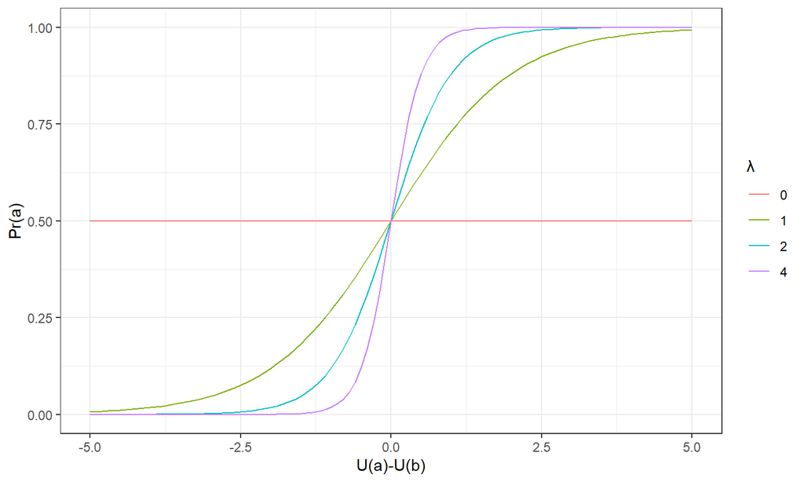

## The quantal response equilibrium condition

\[ \sigma_i=q_i(\sigma,\lambda,\theta)\quad \forall i \]

A fixed point, just like Nash.

This brings with it some of the same problems associated with solving for Nash

Solving for Nash is a PPAD-complete problem (Daskalakis, Goldberg, and Papadimitriou 2009):

- Generally thought to be difficult to solve
- *Very* easy to verify if you have found a solution

## What does QRE look like?

**Example game: Asymmetric chicken** (Goeree, Holt, and Palfrey 2016)

Asymmetric Chicken game

|  | Left | Right |
| --- | --- | --- |
| Up | 0, 0 | 6, 1 |
| Down | 1, 14 | 2, 2 |

\[ \begin{aligned} U_U(\sigma)&=6\sigma_R,\quad U_D(\sigma)=\sigma_L+2\sigma_R\\ U_L(\sigma)&=14\sigma_D, \quad U_R(\sigma)= \sigma_U+2\sigma_D \end{aligned} \]

For this example, I will use the logit probabilistic best response function:

\[ \begin{aligned} q_{i,a}(\sigma,\lambda,\theta)&=\frac{\exp(\lambda u_{i,a}(\sigma,\theta))}{\sum_j\exp(\lambda u_{i,j}(\sigma,\theta))} \end{aligned} \]

## A graphical representation of QRE

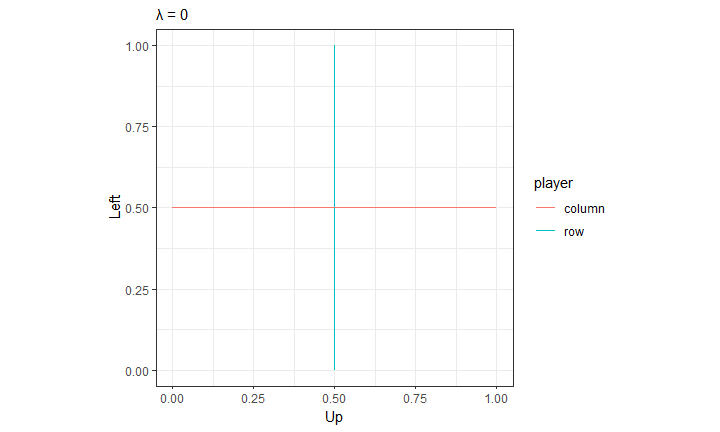

## The logit QRE *correspondence*

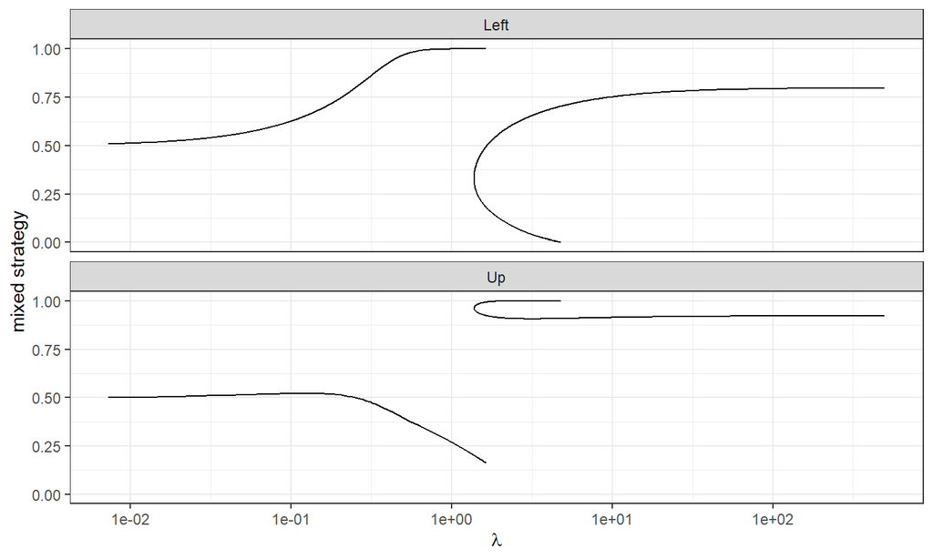

## The logit QRE *locus*

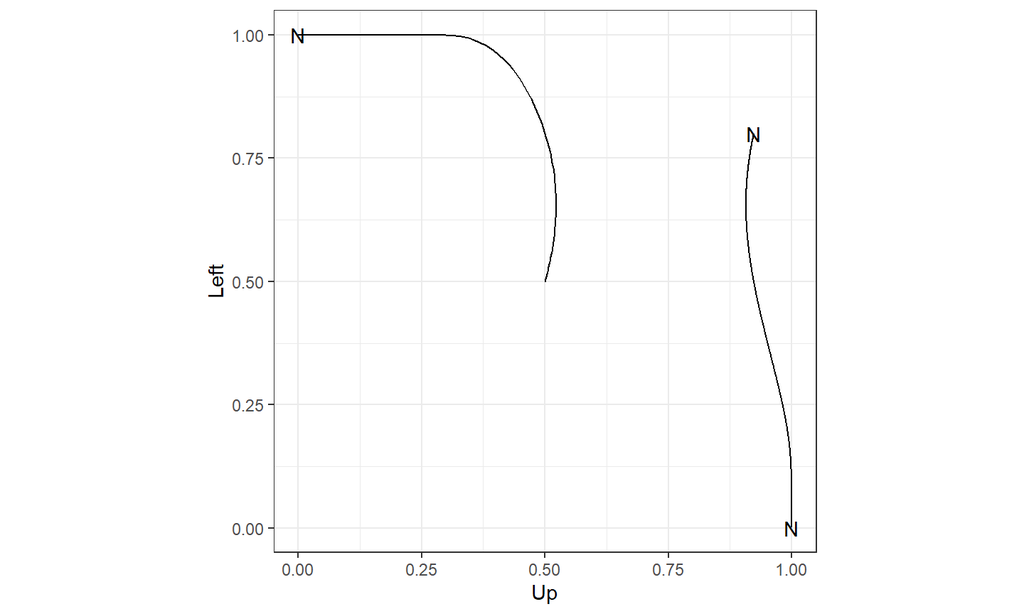

## Existing methods for solving for QRE

\[ \sigma_i=q_i(\sigma,\lambda,\theta),\quad \forall i \]

Many and varied:

- Hope that it is a contraction (no guarantee)
- Minimize sum of squared errors (inefficient)
- Predictor-corrector algorithm (Turocy 2010)
  - Start at a known solution \((\sigma,\lambda,\theta)\)
    - Can always start at the *centroid*: uniform randomization and \(\lambda = 0\)
  - Trace out a “path” or “branch” from here
  - This is what the software package *Gambit* (McKelvey, McLennan, and Turocy 2014) does

## Predictor-corrector algorithm - overview

Starting point: A known solution to \(\sigma= q(\sigma,\lambda,\theta)\)

- “Centroid” is always available to start: \(\lambda = 0\), \(\sigma_{i,a} = \frac{1}{A_i}\)

Predictor step: Propose a nearby solution based on a linear approximation of the system

- Needs derivatives of the system

Corrector step:

- Correct any errors associated with this approximation

## More on the predictor-corrector algorithm

Define a system of equations that characterizes the QRE, e.g.

\[ \begin{aligned} 0&=\log \sigma_{i,a+1}-\log \sigma_{i,a}-\log q_{i,a+1}(\sigma,\lambda,\theta)+\log q_{i,a}(\sigma,\lambda,\theta)\\ 0&=1-\sum_{a=1}^{A_i}\sigma_{i,a} \end{aligned} \]

Call this \(0=G(\sigma,\lambda,\theta)\).

Then use \(\frac{\partial G(\sigma,\lambda,\theta)}{\partial \sigma^\top}\) and \(\frac{\partial G(\sigma,\lambda,\theta)}{\partial \lambda}\) to find a solution nearby.

1. Predictor step: Use these derivatives to approximate the system linearly.
2. Corrector step: correct any errors made with this approximation. Go back to Step 1.

See Bland and Turocy (2023) for a detailed description of how to implement this

## When there is only one path, the predictor-corrector algorithm works well, but…

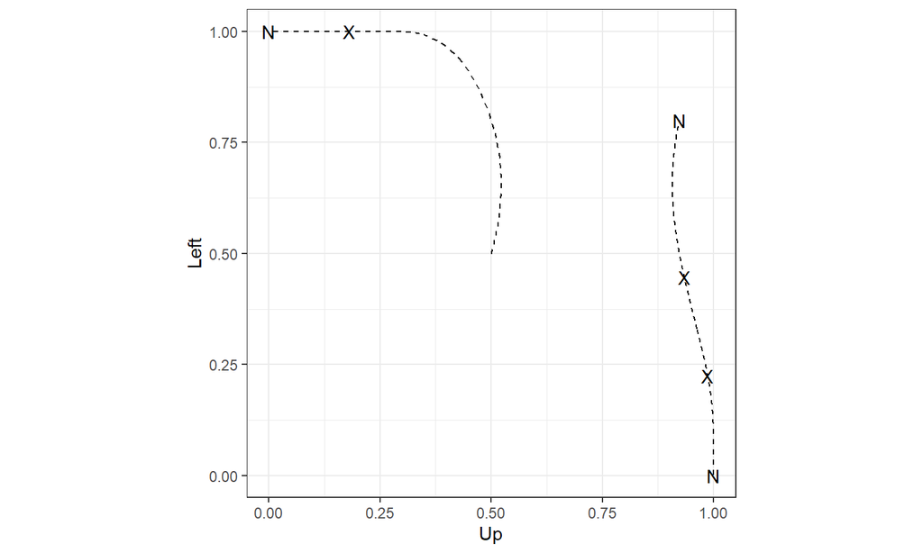

N marks Nash equilibria

X marks QRE for \(\lambda = 1.5\)

## This paper

A **simulation-based** method of approximating QRE

- Construct a distribution whose global modes are quantal response equilibria
- Sample from this distribution

Estimation using Bayesian techniques

## An approximation through simulation

## What this will rely on

We can sample mixed strategy profiles \(\sigma\mid \lambda,\theta\) from distributions that we specify in the following form:

\[ \log p(\sigma\mid \lambda,\theta)=g(\sigma,\lambda,\theta)+c(\lambda,\theta) \]

where:

- \(g(\sigma,\lambda,\theta)\) is a function that we choose, and
- \(c(\lambda,\theta)\) is a normalizing constant.
  - We don’t need to know this part!

This is **exactly** the way probabilistic programming languages like *Stan* (Carpenter et al. 2017) accept information about probability distributions!

## Using the QRE condition

We can write the QRE condition like this:

\[ \begin{aligned} 0&=H_{i,a}(\sigma,\lambda,\theta)\doteq\sigma_{i,a}-q_{i,a}(\sigma,\lambda,\theta)\\ &\forall i\in 1, 2, \ldots n,\quad \forall a \in 1, 2, \ldots, A_i \end{aligned} \]

Therefore for any positive definite weighting matrix \(W\):

\[ \begin{aligned} H(\sigma,\lambda,\theta)^\top WH(\sigma,\lambda,\theta)=0&\iff (\sigma,\lambda,\theta)\text{ is a QRE}\\ H(\sigma,\lambda,\theta)^\top WH(\sigma,\lambda,\theta)>0&\iff (\sigma,\lambda,\theta)\text{ is not a QRE}\\ \end{aligned} \]

## Putting this into a distribution

\[ \log p(\sigma\mid \lambda,\theta)=-H(\sigma,\lambda,\theta)^\top WH(\sigma,\lambda,\theta)+c(\lambda,\theta) \]

Given \((\lambda,\theta)\):

- **Globally** maximized wrt \(\sigma\) at any QRE \((\sigma,\lambda,\theta)\).
- Less probability density elsewhere

The distribution will have **modes** of all the QRE for fixed \((\lambda,\theta)\)

**Practical implications:**

- If we sample \(\sigma\) from this distribution, draws will likely be close to a QRE.
- We can make draws arbitrarily close in probability by increasing \(W\).

## Example: Back to the Asymmetric Chicken game

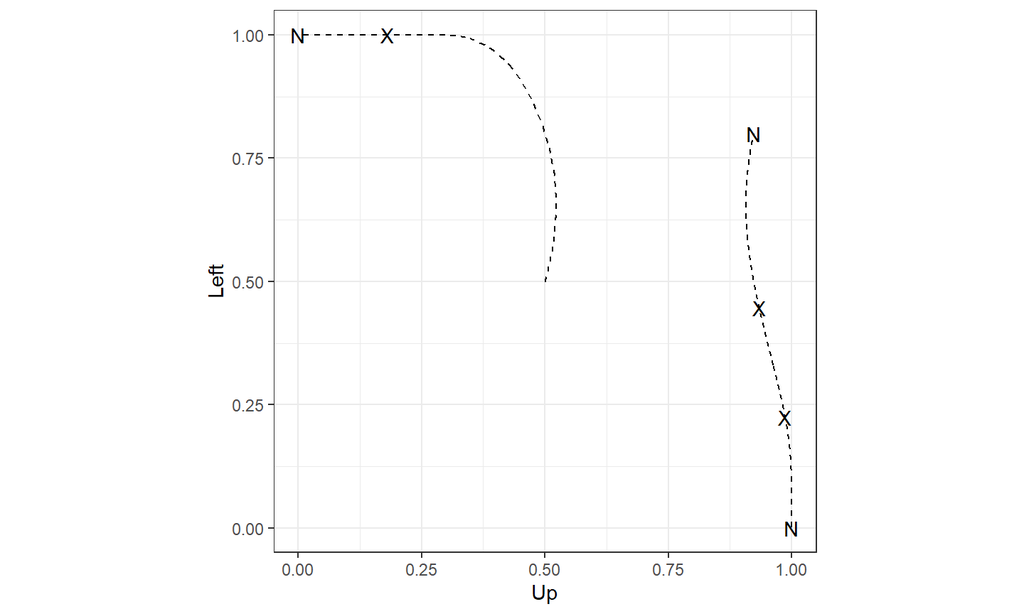

Can the sampler find the equilibria when \(\lambda = 1.5\)?

## Using a Metropolis-Hastings sampler

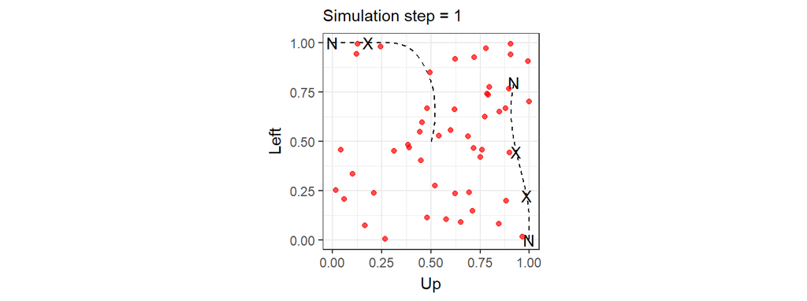

## Implementation in *Stan*

Need to appropriately pick the \(W\) matrix

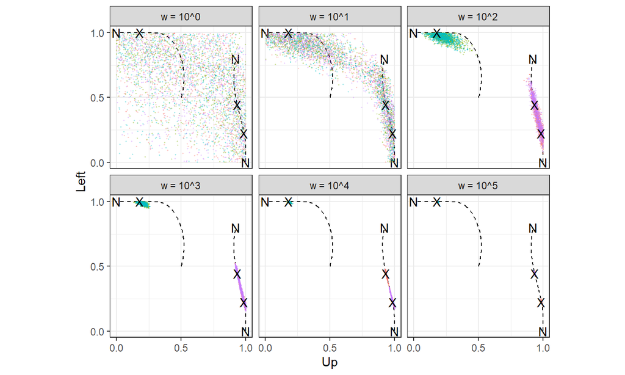

## Diagnosing multiple equilibria

\[ \text{multiuple equilibria} \iff \text{multiple modes} \]

Run more than one Monte Carlo chain with different starting values

- Convergence diagnostics
- Gelman-Rubin statistic \(\hat R\) (Gelman and Rubin 1992)

## Tracing out the QRE locus

Instead of fixing \(\lambda\), assign it a prior:

\[ \log p(\sigma,\lambda\mid \theta)=-H(\sigma,\lambda,\theta)^\top WH(\sigma,\lambda,\theta)+\log p(\lambda \mid \theta) + c(\theta) \]

Sampler now explores the locus of QRE

**Warning:** Don’t use a flat prior!

- Too much mass near Nash equilibrium
- Other parts of the locus will not be discovered

## Using a Metropolis-Hastings sampler

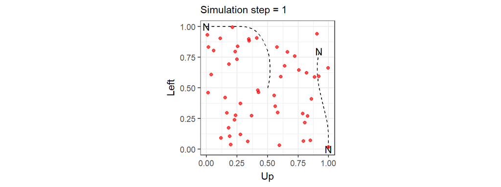

## Implementation in *Stan*

\[ \log\lambda \sim N(\log0.1,0.7^2) \]

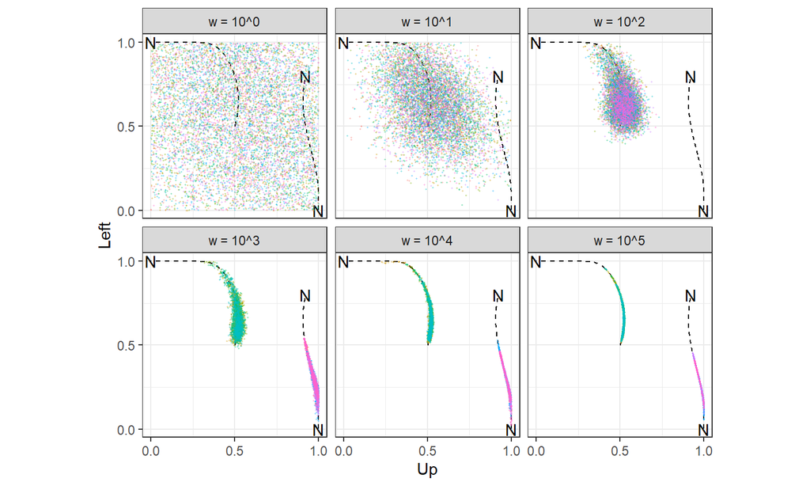

## Eliminating choice precision

In some cases, we can eliminate choice precision from the problem and just focus on mixed strategy profiles.

Logit choice equilibrium condition:

\[ \begin{aligned} 0&=\log\sigma_{i,a+1}-\log \sigma_{i,a}-\lambda\left[u_{i,a+1}(\sigma)-u_{i,a}(\sigma)\right]\\ \hat\lambda &=\arg\min_\lambda\left\{\sum_{\forall i,a}\left(\log\sigma_{i,a+1}-\log \sigma_{i,a}-\lambda\left[u_{i,a+1}(\sigma)-u_{i,a}(\sigma)\right]\right)^2\right\}\\ \hat\lambda&=\frac{\sum_{\forall i,a}\left(\log\sigma_{i,a+1}-\log \sigma_{i,a}\right)\left(u_{i,a+1}(\sigma)-u_{i,a}(\sigma)\right)}{\sum_{\forall i,a}\left(u_{i,a+1}(\sigma)-u_{i,a}(\sigma)\right)^2} \end{aligned} \]

## Then substitute \(\hat\lambda\) into the penalty function

\[ \log p(\sigma \mid\theta)=-H(\sigma,\hat\lambda(\sigma,\theta),\theta)^\top WH(\sigma,\hat\lambda(\sigma,\theta),\theta) + c(\theta) \]

**Prior interpretation:** Conditional on \(\sigma\) being on the locus, \(\sigma\) is uniformly distributed along the locus

- Similar to prior calibrated in Bland (2023)

## Implementation in *Stan*

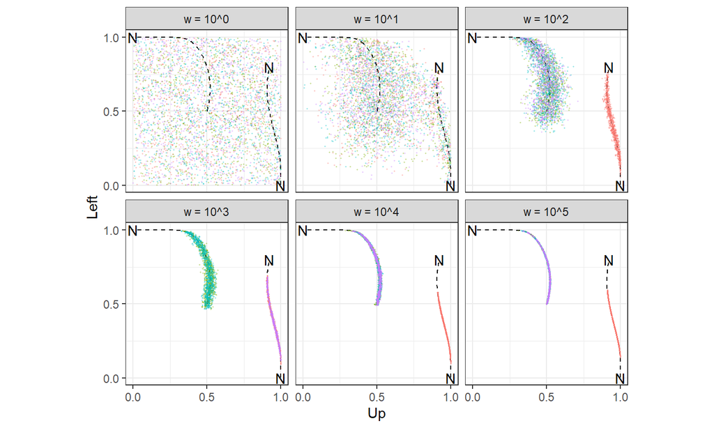

## Estimation

## Combining the distribution with a likelihood

\[ \begin{aligned} p(\sigma,\lambda,\theta\mid y)&\propto p(y\mid \sigma,\lambda,\theta)p(\sigma,\lambda,\theta)\\ &=p(y\mid \sigma,\lambda,\theta)p(\sigma\mid \lambda,\theta)p(\lambda,\theta)\\ \log p(\sigma,\lambda,\theta\mid y)&=y^\top \log \sigma-H(\sigma,\lambda,\theta)^\top WH(\sigma,\lambda,\theta)+\log p(\lambda,\theta)+c \end{aligned} \]

where \(y\) are action counts

## Estimation

- \(\log \lambda \sim N(\log 0.1,0.7^2)\)
- 100 decisions per dataset
- Difficulty finding solutions on the non-principal branch: prior issues

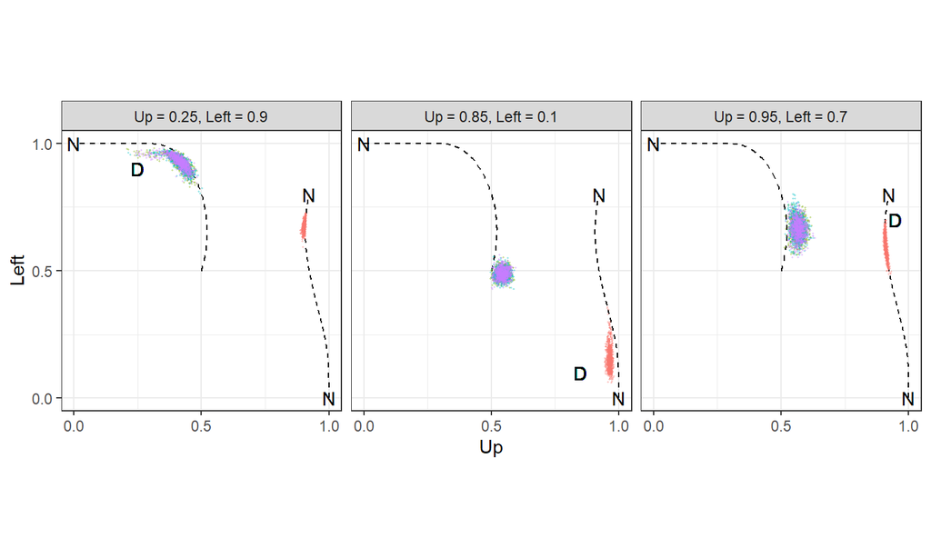

## Multiple (local) modes

Now a bug, not a feature

One chain converged to the wrong branch

Summary statistics of the four Monte Carlo chains shown in the left panel

| chain | posterior means Up | posterior means Left | posterior means lambda | posterior means target log-density |
| --- | --- | --- | --- | --- |
| 1 | 0.90 | 0.67 | 3.17 | -244.18 |
| 2 | 0.41 | 0.92 | 0.43 | -104.52 |
| 3 | 0.42 | 0.92 | 0.41 | -104.41 |
| 4 | 0.41 | 0.93 | 0.45 | -104.56 |

## Conclusion

## A simulation-based approach for computing and estimating QRE

Construct a distribution whose modes are QRE

Sample from this distribution

Tracing the locus:

- use a prior for \(\lambda\)
- eliminate \(\lambda\) for some special cases

Estimating models: Add the likelihood and:

- use a prior for \(\lambda\)
- eliminate \(\lambda\) for some special cases

## Comparison to the predictor-corrector algorithm

**Predictor-corrector**

- Exact solution needed initially for each branch
- Needs derivatives
- Distinction between principal and non-principal branches
- Estimation easy (if on the principal branch). MLE or Bayesian

**Simulation**

- Need a solution close enough to QRE to find it
- No need for derivatives\(^*\)
- No distinction between principal and non-principal branches
- Estimation easy (if not worried about principal branch). Need Bayesian approach

## Should I consider using this?

No, if the predictor-corrector algorithm or something else works well for you.

- More computationally intensive (but maybe less user intensive)

No, if you want to focus on the principal branch and you know there are other branches

Yes, if you want to estimate or compute a QRE with multiple branches and you don’t want to make the distinction between the principal branch and others

Yes, when other techniques struggle

## Are there any more examples?

- Generalized matching pennies with and without risk aversion (Selten and Chmura 2008)
- Volunteer’s Dilemma with heterogeneous preferences (Goeree, Holt, and Smith 2017)
- First-price private-value auction with risk-averse bidders (simulated data)

Implemented in *R* and *Stan*

[figure not shown]

https://github.com/JamesBlandEcon/ApproxQRE

## Next steps

More examples

- Suggestions, please!

For estimation: A sampler that can deal better with multiple global modes

## Thank you

[figure not shown]

https://papers.ssrn.com/sol3/papers.cfm?abstract_id=4774850

## References

Bland, James R. 2023. “Bayesian Inference for Quantal Response Equilibrium in Normal-Form Games.” *Games and Economic Behavior*.

Bland, James R, and Theodore L. Turocy. 2023. “Quantal Response Equilibrium as a Structural Model for Estimation: The Missing Manual.” *Available at SSRN*.

Carpenter, Bob, Andrew Gelman, Matthew D Hoffman, Daniel Lee, Ben Goodrich, Michael Betancourt, Marcus A Brubaker, Jiqiang Guo, Peter Li, and Allen Riddell. 2017. “Stan: A Probabilistic Programming Language.” *Journal of Statistical Software* 76.

Daskalakis, Constantinos, Paul W Goldberg, and Christos H Papadimitriou. 2009. “The Complexity of Computing a Nash Equilibrium.” *Communications of the ACM* 52 (2): 89–97.

Gelman, Andrew, and Donald B Rubin. 1992. “Inference from Iterative Simulation Using Multiple Sequences.” *Statistical Science* 7 (4): 457–72.

Goeree, Jacob K, Charles A Holt, and Thomas R Palfrey. 2016. *Quantal Response Equilibrium: A Stochastic Theory of Games*. Princeton University Press.

Goeree, Jacob K, Charles A Holt, and Angela M Smith. 2017. “An Experimental Examination of the Volunteer’s Dilemma.” *Games and Economic Behavior* 102: 303–15.

McKelvey, Richard D., Andrew M. McLennan, and Theodore L. Turocy. 2014. “Gambit: Software Tools for Game Theory.”

McKelvey, Richard D., and Thomas R. Palfrey. 1995. “Quantal Response Equilibria for Normal Form Games.” *Games and Economic Behavior* 10 (1): 6–38.

Selten, Reinhard, and Thorsten Chmura. 2008. “Stationary Concepts for Experimental 2x2-Games.” *American Economic Review* 98 (3): 938–66.

Turocy, Theodore L. 2010. “Computing Sequential Equilibria Using Agent Quantal Response Equilibria.” *Economic Theory* 42: 255–69.